# BL40A2010 Introduction to IoT-Based Systems

## Assignment 2, 16.09.2023

### Author: Martyna Pitera

**(1) Give one example of each of the following type of data.**

Answer:

(a) Analog: Live, in class lecture of course Introduction to IoT-Based Systems

(b) Digital: Lecture of course Introduction to IoT-Based Systems recorded and watched using laptop

(c) Primary: equations

(d) Secondary (i.e., lack of data that is informative): no sound outside

(e) Metadata: picture's date and location

(f) Environmental: outside temperature measured with thermometer, or tree outside my office indicatating the season of the year (green leaves, no leaf)

**(2) Write one example when the same structured data can be classified as (a) information, (b) redundancy and (c) not interpretable.**

Answer: a) date of birth of a person I didn't know before b) my date of birth, it's reduncancy because for sure I have already know this date c) when someone speaks another language and I can't understand what is he talking about, this is not interpretable for me

**(3) Photo-voltaic generation converts the sun's radiation into usable electricity. In this task, you will get the *direct solar radiation* with 1 minute time interval from the *Radiation observations* at [FMI](http://en.ilmatieteenlaitos.fi/download-observations#!/). Plot radiation profile of three different days so that one must be in March, other in July and the last in December (regardless of the year). What measuring station was used? Compare the solar radiation in those 3 days and provide *information* about the potential of solar generation in those days. You can also select the measuring station (but write it in the answer).**

*Hint:* Code like in the tutorial notebook.

```
<class 'pandas.core.frame.DataFrame'>
DatetimeIndex: 1441 entries, 2022-12-01 00:00:00 to 2022-12-02 00:00:00
Data columns (total 1 columns):
 #   Column                         Non-Null Count  Dtype
---  ------                         --------------  -----
 0   Direct solar radiation (W/m2)  1441 non-null   float64
dtypes: float64(1)
memory usage: 22.5 KB
```

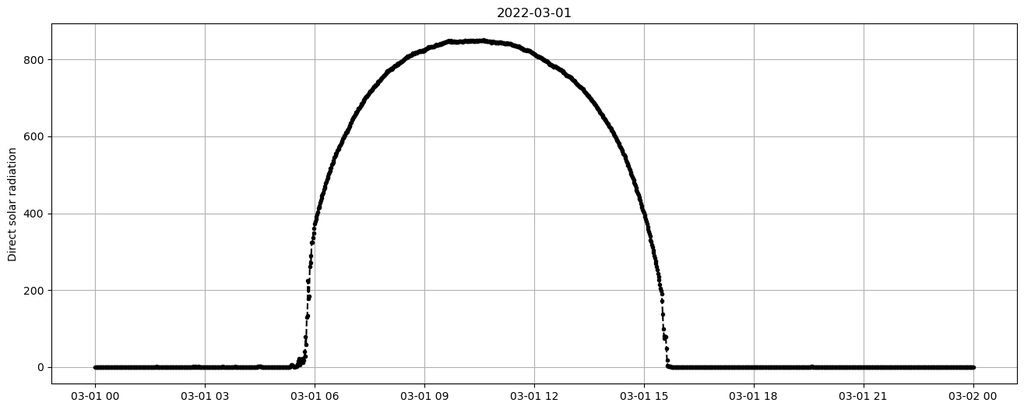

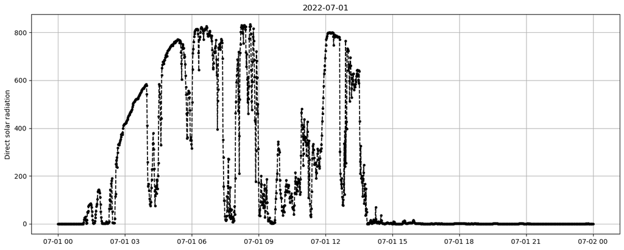

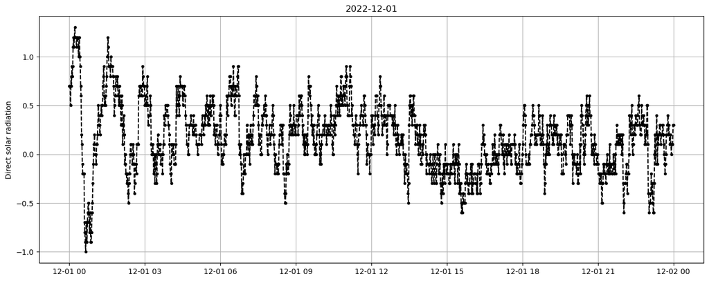

```python
#used station: Helsinki Kumpula
import pandas as pd
import matplotlib.pyplot as plt
import matplotlib.dates as mdates

march = pd.read_csv("march1.csv", dayfirst=True, sep=",", header=0, decimal=b".",index_col=0,
                           parse_dates= [[0, 1, 2, 3]],usecols=[0,1,2,3,5])
july = pd.read_csv("july1.csv", dayfirst=True, sep=",", header=0, decimal=b".",index_col=0,
                           parse_dates= [[0, 1, 2, 3]],usecols=[0,1,2,3,5])
dec = pd.read_csv("dec1.csv", dayfirst=True, sep=",", header=0, decimal=b".",index_col=0,
                           parse_dates= [[0, 1, 2, 3]],usecols=[0,1,2,3,5])
dec.info()

#Day 1
day1 = '2022-03-01'
plt.figure(figsize=(16,6))
plt.plot(march,color='black', marker='.',linestyle='--')
plt.title(day1)
plt.ylabel("Direct solar radiation")
plt.grid(True)
plt.show()

#Day 2
day2 = '2022-07-01'
plt.figure(figsize=(16,6))
plt.plot(july,color='black', marker='.',linestyle='--')
plt.title(day2)
plt.ylabel("Direct solar radiation")
plt.grid(True)
plt.show()

#Day 3
day3 = '2022-12-01'
plt.figure(figsize=(16,6))
plt.plot(dec,color='black', marker='.',linestyle='--')
plt.title(day3)
plt.ylabel("Direct solar radiation")
plt.grid(True)
plt.show()

#Considering solar radiation in given 3 days, potential solar generation is the best on 2022-03-01.
#In March, potential solar generation is high for long period of the day and it is very stable. In July, potential solar generation is high for long period of the day, but it is very unstable. In December, potential solar generation is low for a whole day and it is very unstable..
```

**(4) Read the text [What Does the Metaverse Mean for the Future of Energy Consumption?](https://earth.org/metaverse-energy-consumption/). Write a brief analysis of the text based on the relation between data, energy and level of processes. From the energy perspective, is it possible to maintain this kind of technologies? Note: This is clearly not a right/wrong question, but a space to critically think about current issues related to the course.**

Answer: Based on the text, the more data centres come online, the higher is electricity usage. New technologies and, using AI or VR require costly data processing, so developing and using them leads to more electricity usage. Such technologies require running many complicated processes, and they can't be stopped - everything must run smoothly without breaks, so technologies like the Metaverse may work properly. As mentioned in the text, technologies like the Metaverse could limit travel emissions, since people would be able to work without commuting and also people wouldn't take planes to go for concerts etc. But still, if the Metaverse is to use AI tools, these models are said to leave a big carbon footprint, so limitting travel emissions with increasing carbon footprint makes in the same time, it makes no sense. Moreover, if we want to globally use technologies like the Metaverse, we need to increase the level of processes, make more powerful infractructure. More power = more energy usage. As for the definition of Level of processes from the lecture notes, I would say that the Metaverse is classified into Level-N. From the energy perspective, I think maybe it is possible to maintain this kind of technologies, but not now, and not even in the near future. Even though there are many eco-friendly innovations visible, the world is far away from being 100% eco-friendly. In my opinion, now it's more important to increase renewable energy production in every country, and only then we can start thinking about this abstract projects like the Metaverse. If it needs very powerful computing infrastructe, we need to ensure that it can use renewable energy first.